# Vícerozměrná analýza dat

[GitHub Repo](https://github.com/sedamichal/XAVDT/blob/main/semestral%20paper/Projekt_Vicerozmerna_Analyza.ipynb)

# Aplikace PCA, shlukové analýzy a LDA na chemických vlastnostech vín

**Autor:** Michal Šeda  
**Dataset:** Wine Recognition Data (UCI ML Repository)  
**Metody:** PCA, K-means, Hierarchické shlukování, LDA

## Úvod a formulace úlohy

### Popis úlohy

Cílem tohoto projektu je aplikovat metody vícerozměrné analýzy dat na reálný dataset chemických vlastností vín z různých odrůd. Dataset obsahuje **178 vzorků vín** ze tří různých odrůd révy vinné pěstovaných ve stejné oblasti Itálie. Pro každý vzorek je k dispozici **13 chemických proměnných**.

### Zdroj dat

[**UCI Machine Learning Repository - Wine Recognition Data**](https://archive.ics.uci.edu/ml/datasets/wine)

**Dataset:** 178 vzorků vín ze 3 odrůd révy vinné z Itálie  
**Proměnné:** 13 chemických parametrů

#### Přehled parametrů Wine datasetu

##### 1. ALCOHOL (Alkohol)

- **Jednotka:** % obj.
- **Popis:** Obsah ethanolu ve víně. Vyšší hodnoty = silnější víno. Ovlivňuje chuť, tělo a stabilitu.
- **Interpretace:** ↑ = silnější víno, vyšší extraktivita
- **Typický rozsah:** 11-15%

##### 2. MALIC ACID (Kyselina jablečná)

- **Jednotka:** g/L
- **Popis:** Hlavní organická kyselina v hroznech. Ovlivňuje kyselost a čerstvost vína. Klesá při dozrávání hroznů.
- **Interpretace:** ↑ = kyselejší, čerstvější víno
- **Poznámka:** Během malolaktické fermentace se přeměňuje na kyselinu mléčnou

##### 3. ASH (Popel)

- **Jednotka:** g/L
- **Popis:** Anorganické minerály zbylé po spálení vína. Indikátor minerálního složení půdy.
- **Interpretace:** ↑ = vyšší minerální obsah
- **Obsahuje:** K, Ca, Mg, Na, Fe a další minerály

##### 4. ALCALINITY OF ASH (Alkalinita popela)

- **Jednotka:** meq/L (miliekvivalenty na litr)
- **Popis:** Schopnost popela neutralizovat kyseliny. Souvisí s obsahem draslíku, vápníku a hořčíku.
- **Interpretace:** ↑ = vyšší pH, nižší kyselost
- **Souvisí s:** Pufrační kapacitou vína

##### 5. MAGNESIUM (Hořčík)

- **Jednotka:** mg/L
- **Popis:** Důležitý minerál z půdy. Ovlivňuje enzymatické reakce při fermentaci. Indikátor terroir.
- **Interpretace:** ↑ = bohatší půda, lepší terroir
- **Rozsah:** 70-162 mg/L v datasetu

##### 6. TOTAL PHENOLS (Celkové fenoly)

- **Jednotka:** g/L
- **Popis:** Suma všech fenolických sloučenin. Antioxidanty, ovlivňují barvu, chuť a stárnutí vína.
- **Interpretace:** ↑ = větší antioxidační kapacita
- **Zahrnuje:** Flavonoidy + neflavonoidní fenoly
- **Význam:** Nejvyšší u červených vín

##### 7. FLAVANOIDS (Flavonoidy)

- **Jednotka:** g/L
- **Popis:** Podskupina fenolů. Hlavní antioxidanty, ovlivňují barvu (červená), chuť (trpkost) a zdravotní přínosy.
- **Interpretace:** ↑ = silnější barva, více tříslovin
- **Zahrnuje:** Katechiny, anthokyaniny, quercetin
- **KLÍČOVÝ PARAMETR pro rozlišení odrůd!**

##### 8. NONFLAVANOID PHENOLS (Neflavonoidní fenoly)

- **Jednotka:** g/L
- **Popis:** Fenoly bez flavonoidní struktury. Menší vliv na barvu, ale přispívají k celkové chuti.
- **Interpretace:** ↓ = čistší flavonoidní profil
- **Zahrnuje:** Kyselina gallová, kyselina kávová, tyrosol

##### 9. PROANTHOCYANINS (Proanthokyaniny)

- **Jednotka:** mg/L
- **Popis:** Typ flavonoidů (kondenzované taniny). Zodpovědné za trpkost a "tělnatost" červených vín. Stabilizují barvu.
- **Interpretace:** ↑ = trpčí, tělnatější víno
- **Pocit:** "Sucho" v ústech po červeném víně

##### 10. COLOR INTENSITY (Intenzita barvy)

- **Jednotka:** bezrozměrná (absorbance)
- **Popis:** Měří intenzitu/sytost barvy vína. Vyšší u červených vín, nižší u bílých.
- **Interpretace:** ↑ = tmavší, sytější barva
- **Měření:** Spektrofotometricky

##### 11. HUE (Odstín)

- **Jednotka:** bezrozměrná (poměr absorbancí)
- **Popis:** Odstín/tón barvy.
  - Nízké hodnoty = červená/fialová (mladá vína)
  - Vysoké hodnoty = oranžová/hnědá (oxidace, stárnutí)
- **Interpretace:** ↓ = mladší, ↑ = starší/oxidované
- **Výpočet:** OD420/OD520

##### 12. OD280/OD315 OF DILUTED WINES (OD280/OD315 zředěných vín)

- **Jednotka:** poměr (bezrozměrný)
- **Popis:** Poměr absorbancí UV světla při 280 nm a 315 nm. Indikátor obsahu proteinů a fenolů.
- **Interpretace:** ↑ = vyšší kvalita, více proteinů a fenolů
- **Proč zředěné?** Čisté víno je příliš tmavé pro přesné měření
- **OD280:** Zachycuje proteiny + fenoly
- **OD315:** Zachycuje flavonoidy + barevné látky
- **RYCHLÝ TEST kvality vína!**

##### 13. PROLINE (Prolin)

- **Jednotka:** mg/L
- **Popis:** Aminokyselina. Nejvíce zastoupená aminokyselina ve víně (až 85%). Ovlivňuje nutriční hodnotu a chuť.
- **Interpretace:** ↑ = nutriční hodnota, plnost
- **Rozsah:** 278-1680 mg/L v datasetu (obrovská variabilita!)
- **Zajímavost:** Některé odrůdy mají 10× vyšší obsah než jiné

#### Skupiny parametrů

##### 1. ZÁKLADNÍ SLOŽENÍ

- **Alcohol** - hlavní alkohol
- **Malic acid** - hlavní kyselina
- **Ash, Alcalinity, Magnesium** - minerální složení (terroir)

##### 2. FENOLICKÉ SLOUČENINY

*(Antioxidanty, barva, chuť)*

- **Total phenols** - celkový obsah fenolů
- **Flavanoids** - hlavní barevné a tříslovinové látky
- **Nonflavanoid phenols** - doplňkové fenoly
- **Proanthocyanins** - třísloviny (trpkost)

##### 3. OPTICKÉ VLASTNOSTI

- **Color intensity** - síla barvy
- **Hue** - odstín barvy (mladé vs. staré)
- **OD280/OD315** - spektrofotometrický ukazatel kvality

##### 4. AMINOKYSELINY

- **Proline** - hlavní aminokyselina

#### Praktické využití

##### Pro vinaře:

- **Flavonoidy + Total phenols** → kvalita, potenciál stárnutí
- **Malic acid** → čerstvost, vhodnost pro malolaktickou fermentaci
- **Proline** → typické pro určité odrůdy
- **Hue** → monitorování oxidace/stárnutí

##### Pro analytiky:

- **OD280/OD315** → rychlý test kvality (nemusí se měřit všechny fenoly samostatně)
- **Magnesium + Alkalinita** → "otisk prstu" půdy/terroir
- **Color intensity + Hue** → vizuální kvalita

##### Pro spotřebitele:

- **Alcohol** → síla vína
- **Proanthocyanins** → trpkost červených vín
- **Total phenols** → antioxidační přínosy

*Reference* Jackson, R.S. (2008). Wine Science: Principles and Applications

## Explorační analýza dat (EDA)

Metadata datasetu

| Vlastnost | Hodnota |
| --- | --- |
| Počet vzorků | 178 |
| Počet proměnných | 13 |

Seznam sledovaných odrůd

| Odrůda 1 |
| --- |
| Odrůda 2 |
| Odrůda 3 |

Rozdělení vzorků v třídách

| Odrůda | Počet vzorků |
| --- | --- |
| Odrůda 1 | 59 |
| Odrůda 2 | 71 |
| Odrůda 3 | 48 |

Popisná statistika

| Statistika | alcohol | malic_acid | ash | alcalinity_of_ash | magnesium | total_phenols | flavanoids | nonflavanoid_phenols | proanthocyanins | color_intensity | hue | od280/od315_of_diluted_wines | proline |
| --- | --- | --- | --- | --- | --- | --- | --- | --- | --- | --- | --- | --- | --- |
| count | 178.00 | 178.00 | 178.00 | 178.00 | 178.00 | 178.00 | 178.00 | 178.00 | 178.00 | 178.00 | 178.00 | 178.00 | 178.00 |
| mean | 13.00 | 2.34 | 2.37 | 19.49 | 99.74 | 2.30 | 2.03 | 0.36 | 1.59 | 5.06 | 0.96 | 2.61 | 746.89 |
| std | 0.81 | 1.12 | 0.27 | 3.34 | 14.28 | 0.63 | 1.00 | 0.12 | 0.57 | 2.32 | 0.23 | 0.71 | 314.91 |
| min | 11.03 | 0.74 | 1.36 | 10.60 | 70.00 | 0.98 | 0.34 | 0.13 | 0.41 | 1.28 | 0.48 | 1.27 | 278.00 |
| 25% | 12.36 | 1.60 | 2.21 | 17.20 | 88.00 | 1.74 | 1.21 | 0.27 | 1.25 | 3.22 | 0.78 | 1.94 | 500.50 |
| 50% | 13.05 | 1.87 | 2.36 | 19.50 | 98.00 | 2.35 | 2.13 | 0.34 | 1.56 | 4.69 | 0.96 | 2.78 | 673.50 |
| 75% | 13.68 | 3.08 | 2.56 | 21.50 | 107.00 | 2.80 | 2.88 | 0.44 | 1.95 | 6.20 | 1.12 | 3.17 | 985.00 |
| max | 14.83 | 5.80 | 3.23 | 30.00 | 162.00 | 3.88 | 5.08 | 0.66 | 3.58 | 13.00 | 1.71 | 4.00 | 1,680.00 |

Ukázka dat

| alcohol | malic_acid | ash | alcalinity_of_ash | magnesium | total_phenols | flavanoids | nonflavanoid_phenols | proanthocyanins | color_intensity | hue | od280/od315_of_diluted_wines | proline | cultivar | cultivar_name |
| --- | --- | --- | --- | --- | --- | --- | --- | --- | --- | --- | --- | --- | --- | --- |
| 14.23 | 1.71 | 2.43 | 15.6 | 127.0 | 2.8 | 3.06 | 0.28 | 2.29 | 5.64 | 1.04 | 3.92 | 1065.0 | 0 | Odrůda 1 |
| 13.2 | 1.78 | 2.14 | 11.2 | 100.0 | 2.65 | 2.76 | 0.26 | 1.28 | 4.38 | 1.05 | 3.4 | 1050.0 | 0 | Odrůda 1 |
| 13.16 | 2.36 | 2.67 | 18.6 | 101.0 | 2.8 | 3.24 | 0.3 | 2.81 | 5.68 | 1.03 | 3.17 | 1185.0 | 0 | Odrůda 1 |
| 14.37 | 1.95 | 2.5 | 16.8 | 113.0 | 3.85 | 3.49 | 0.24 | 2.18 | 7.8 | 0.86 | 3.45 | 1480.0 | 0 | Odrůda 1 |
| 13.24 | 2.59 | 2.87 | 21.0 | 118.0 | 2.8 | 2.69 | 0.39 | 1.82 | 4.32 | 1.04 | 2.93 | 735.0 | 0 | Odrůda 1 |

Chybějící hodnoty: 0  
Dataset neobsahuje chybějící hodnoty

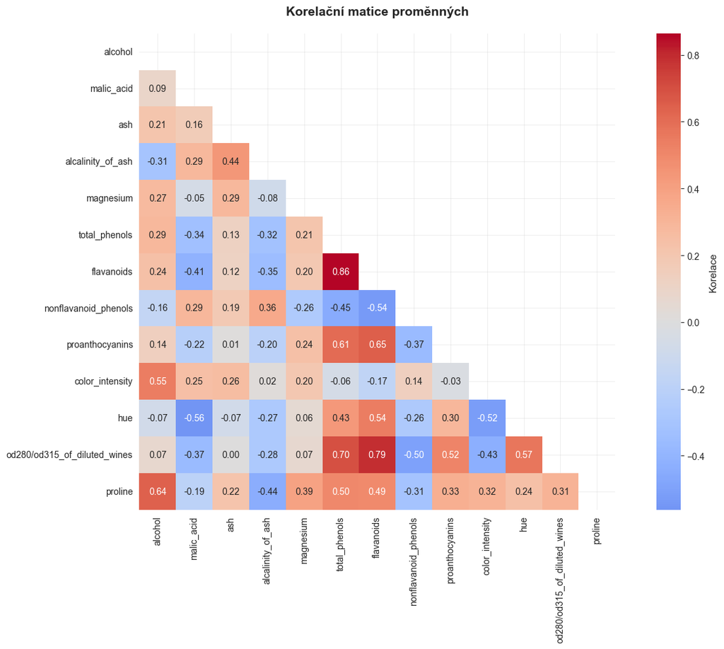

Nejsilnější pozitivní korelace

|  |  | Korelace |
| --- | --- | --- |
| total_phenols | flavanoids | 0.8646 |
| flavanoids | od280/od315_of_diluted_wines | 0.7872 |
| total_phenols | od280/od315_of_diluted_wines | 0.6999 |
| flavanoids | proanthocyanins | 0.6527 |
| alcohol | proline | 0.6437 |

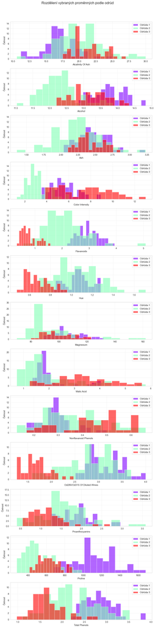

## Předzpracování dat - Standardizace

Průměr po standardizaci (měl by být ~0): 0.000000  
Směrodatná odchylka po standardizaci (měla by být ~1): 1.000000

## Analýza hlavních komponent (PCA)

PCA redukuje dimenzionalitu dat transformací do nového prostoru hlavních komponent, které zachycují maximální variabilitu.

#### Vlastní čísla

Vlastní čísla

| PC | Vlastní číslo | % | Kumulativní % |
| --- | --- | --- | --- |
| 1.00 | 4.73 |  | 36 |
| 2.00 | 2.51 |  | 55 |
| 3.00 | 1.45 |  | 67 |
| 4.00 | 0.92 |  | 74 |
| 5.00 | 0.86 |  | 80 |
| 6.00 | 0.65 |  | 85 |
| 7.00 | 0.55 |  | 89 |
| 8.00 | 0.35 |  | 92 |
| 9.00 | 0.29 |  | 94 |
| 10.00 | 0.25 |  | 96 |
| 11.00 | 0.23 |  | 98 |
| 12.00 | 0.17 |  | 99 |
| 13.00 | 0.10 |  | 100 |

#### Kaiserovo pravidlo (Kaiser Criterion)

Používá se hlavně v případě, kdy je PCA prováděno na standardizovaných datech (korelační matice).

**Pravidlo:** Ponechat pouze ty $PC$, jejichž vlastní číslo $\lambda > 1$.

**Proč:** Vlastní číslo $\lambda = 1$ odpovídá rozptylu jedné původní proměnné. Pokud komponenta nevysvětlí ani tolik, co jedna původní proměnná, nemá smysl ji držet.

#### Vlastní vektory

Vlastní vektory

| Vlastnost | PC1 | PC1_% | PC1_%_CSUM | PC2 | PC2_% | PC2_%_CSUM | PC3 | PC3_% | PC3_%_CSUM |
| --- | --- | --- | --- | --- | --- | --- | --- | --- | --- |
| alcalinity_of_ash | −0.52 | 7 | 88 | −0.02 | 0 | 100 | 0.74 | 22 | 44 |
| alcohol | 0.31 | 4 | 93 | 0.77 | 17 | 36 | −0.25 | 7 | 52 |
| ash | −0.00 | 0 | 100 | 0.50 | 11 | 60 | 0.76 | 22 | 22 |
| color_intensity | −0.19 | 3 | 100 | 0.84 | 19 | 19 | −0.17 | 5 | 85 |
| flavanoids | 0.92 | 13 | 13 | −0.01 | 0 | 100 | 0.18 | 5 | 69 |
| hue | 0.65 | 9 | 65 | −0.44 | 10 | 81 | 0.10 | 3 | 100 |
| magnesium | 0.31 | 4 | 97 | 0.47 | 11 | 71 | 0.16 | 5 | 89 |
| malic_acid | −0.53 | 8 | 81 | 0.36 | 8 | 89 | 0.11 | 3 | 97 |
| nonflavanoid_phenols | −0.65 | 9 | 56 | 0.05 | 1 | 100 | 0.21 | 6 | 58 |
| od280/od315_of_diluted_wines | 0.82 | 12 | 37 | −0.26 | 6 | 95 | 0.20 | 6 | 64 |
| proanthocyanins | 0.68 | 10 | 46 | 0.06 | 1 | 98 | 0.18 | 5 | 74 |
| proline | 0.62 | 9 | 73 | 0.58 | 13 | 49 | −0.15 | 5 | 94 |
| total_phenols | 0.86 | 12 | 25 | 0.10 | 2 | 97 | 0.18 | 5 | 80 |

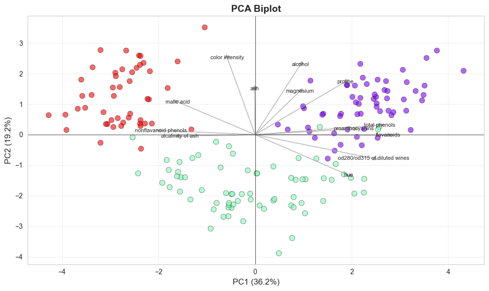

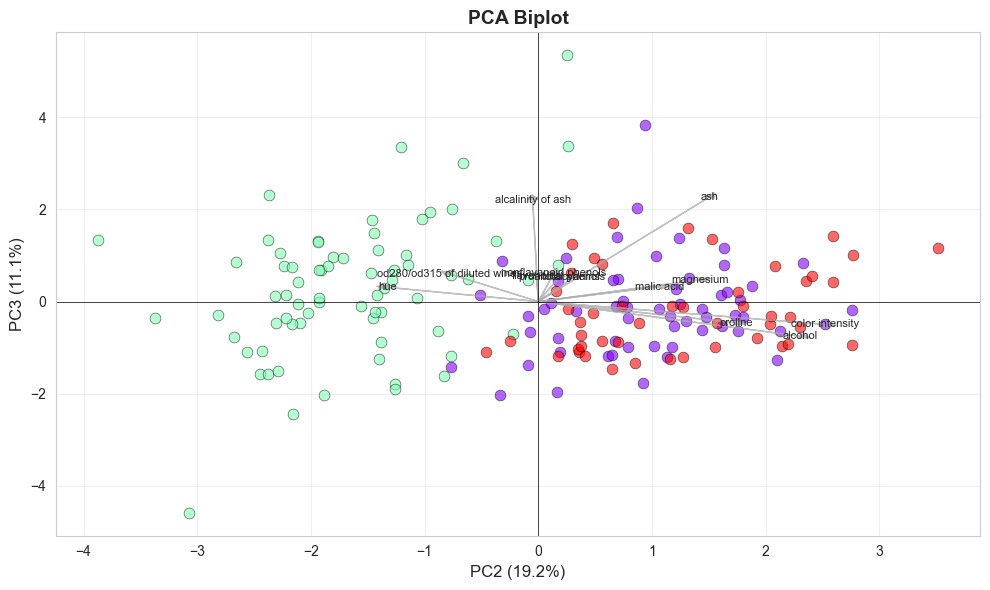

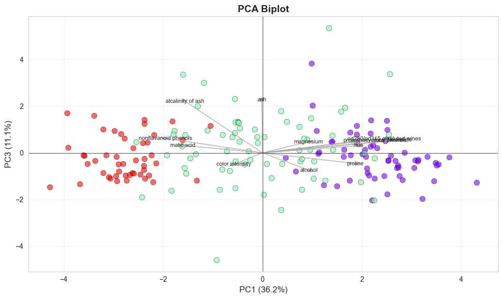

### Interpretace PCA:

- První komponenta (PC1) vysvětluje **36,2% variability** a je silně korelována s fenolickými sloučeninami (flavonoidy, celkové fenoly)
- Druhá komponenta (PC2) vysvětluje **19,2% variability**
- Celkem první dvě komponenty zachycují **55,4% celkové variability**
- Odrůdy jsou částečně oddělitelné v PC prostoru
- PC3 je silně ovlivněna proměnnou Ash a Alcanility of Ash

#### Odlišení odrůd

- **Nejlepší pohled (PC1 vs PC2):**  
  nejčistší rozdělení. PC1 a PC2 dohromady vysvětlují přes 55 % celkové variability dat, což je důvod, proč je tento pohled nejinformativnější.
- **Slabší separace (PC2 vs PC3):**  
  velký překryv mezi Odrůdou 1 a 3. To znamená, že třetí komponenta (PC3) nepřidává mnoho informací pro jejich rozlišení.

## Shluková analýza

### K-means clustering

#### K-means pro více počtů clusterů

Metriky podle počtu clusterů

| Počet clusterů | ARI | SIL |
| --- | --- | --- |
| 2 | 0.37 | 0.27 |
| 3 | 0.90 | 0.28 |
| 4 | 0.82 | 0.25 |
| 5 | 0.63 | 0.18 |

#### Metodika výběru počtu clasterů pro K-means

Pro určení optimálního počtu clusterů byla použita metoda grid-search, ze které při vyhodnocení ARI (Adjusted Rand Index) byl nejlepší výsledek s počtem 3, což se shoduje s počtem odrůd.

#### Interpretace K-means

- **Vysoké ARI**:  
  ukazuje na správné nalezení skupin, tedy že odrůdy byly identifikovány správně.
- **Nízká hodnota SIL (Silhouette score)**:  
  separace není dobrá, tzn. že chemické vlastnosti odrůd se překrývají, což je přirozené a u dat biologického původu běžné, nebo je to důsledek vysoké dimenzionality, metoda K-means navíc předpokládá sférické clustery stejné velikosti, což nemusi struktuře dat odpovídat

#### Vizualizace K-means v PCA prostoru

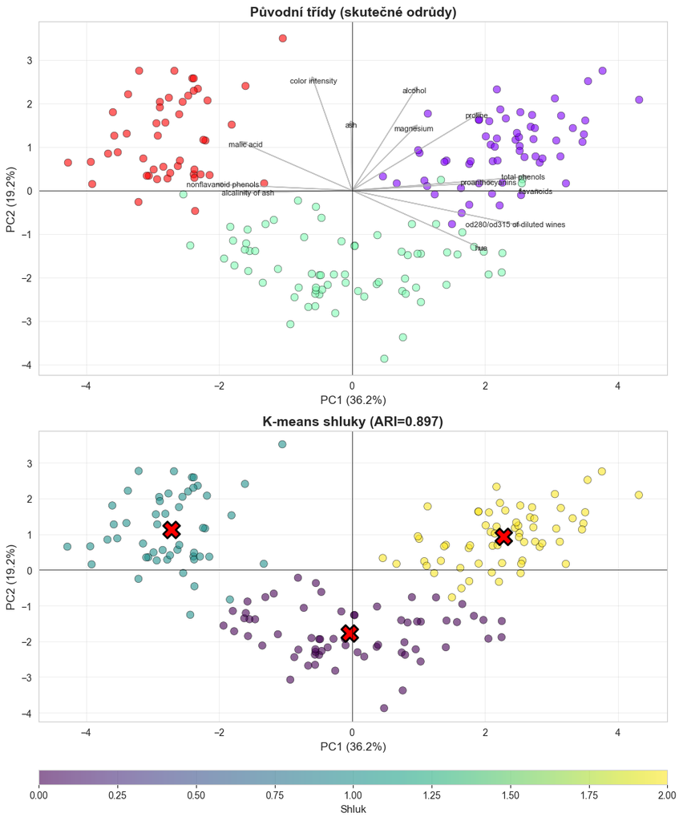

Srovnání Shluků a Odrůd

| Predikovaný Shluk | Odrůda 1 | Odrůda 2 | Odrůda 3 |
| --- | --- | --- | --- |
| 0 | 0 | 65 | 0 |
| 1 | 0 | 3 | 48 |
| 2 | 59 | 3 | 0 |

### Hierarchické shlukování

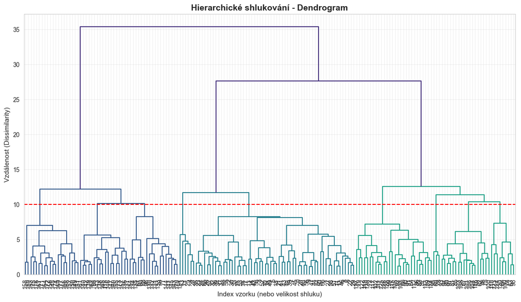

Srovnání Shluků a Odrůd

| Predikovaný Shluk | Odrůda 1 | Odrůda 2 | Odrůda 3 |
| --- | --- | --- | --- |
| 1 | 0 | 8 | 48 |
| 2 | 59 | 5 | 0 |
| 3 | 0 | 58 | 0 |

## Lineární diskriminační analýza (LDA)

LDA hledá lineární kombinace proměnných, které maximálně oddělují předem definované třídy. Na rozdíl od PCA je to metoda řízená (supervised).

Přesnost klasifikace (LDA): 100.00%

|  | Vysvětlený rozptyl diskriminačními funkcemi |
| --- | --- |
| LD1 | 0.69 |
| LD2 | 0.31 |

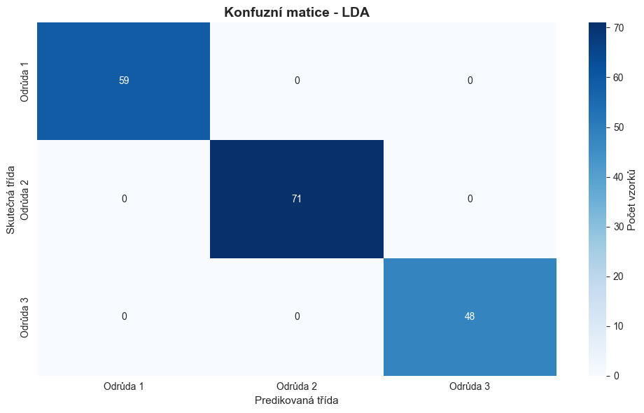

Klasifikační Report

| Třída / Metrika | Precision | Recall | F1-Score | Support |
| --- | --- | --- | --- | --- |
| Odrůda 1 | 1.000 | 1.000 | 1.000 | 59 |
| Odrůda 2 | 1.000 | 1.000 | 1.000 | 71 |
| Odrůda 3 | 1.000 | 1.000 | 1.000 | 48 |
| accuracy | 1.000 | 1.000 | 1.000 | 1 |
| macro avg | 1.000 | 1.000 | 1.000 | 178 |
| weighted avg | 1.000 | 1.000 | 1.000 | 178 |

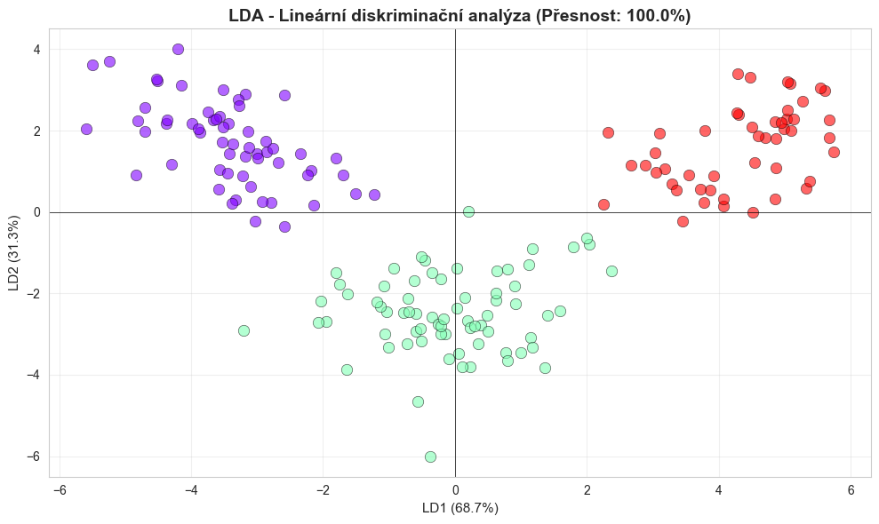

Nejvýznamnější rysy pro LD1

| index | LD1 | LD2 |
| --- | --- | --- |
| flavanoids | −1.65 | −0.49 |
| proline | −0.85 | 0.90 |
| color_intensity | 0.82 | 0.59 |
| od280/od315_of_diluted_wines | −0.82 | 0.04 |
| alcalinity_of_ash | 0.52 | −0.49 |

Nejvýznamnější rysy pro LD2

| index | LD1 | LD2 |
| --- | --- | --- |
| proline | −0.85 | 0.90 |
| alcohol | −0.33 | 0.71 |
| ash | −0.10 | 0.64 |
| color_intensity | 0.82 | 0.59 |
| flavanoids | −1.65 | −0.49 |

## Závěr a interpretace

### Hlavní zjištění:

1. **PCA**
   - První dvě komponenty zachycují **55,4% variability**
   - Hlavní faktor variability: **fenolické sloučeniny** (flavonoidy, celkové fenoly)
   - Odrůdy jsou částečně oddělitelné v PC prostoru
2. **Shluková analýza**
   - K-means: Velmi vysoká shoda s původními třídami (**ARI = 0,897**), ale horší separabilita
   - Hierarchické shlukování potvrzuje existenci **3 přirozených shluků**
   - Data mají jasnou strukturu odpovídající třem odrůdám
3. **LDA (Lineární diskriminační analýza)**
   - Dosažena **100% přesnost klasifikace**
   - Odrůdy vín jsou **perfektně lineárně separabilní**
   - LDA poskytuje nejlepší oddělení tříd (supervised metoda)

### Praktický význam:

- Chemické vlastnosti umožňují **spolehlivou identifikaci odrůd vín**
- Metody vícerozměrné analýzy jsou účinným nástrojem pro:
  - Kontrolu kvality vín
  - Detekci falšování
  - Certifikaci původu
  - Charakterizaci odrůd

### Doporučení:

- Pro **exploraci dat** → PCA
- Pro **hledání přirozených skupin** → Shluková analýza
- Pro **klasifikaci se známými třídami** → LDA
- V praxi: kombinace všech metod poskytuje nejkomplexnější pohled na data